# R Notebook

Jackie Yang

### Question 1: A researcher is interested in the effect of two different culture media and two different times on the growth of a certain bacteria. Making the runs in a random order, she has collected data on the growth of the bacteria under each factor combination levels. Data can be found in virus.csv file.

### (a). Recognize the experimental units, factors of interest and the response variable in this study.

### The experimental units are the bacteria. Factors of interest are two different culture media and two different times. The response variable is the growth of the bacteria.

### (b). Use aggregate() function to find the means for factor level combination.

```r
bacteria_data <- read.csv("bacteria.csv")
mean_growth <- aggregate(Growth ~ Culture + Time, data = bacteria_data, FUN = mean)
names(mean_growth) <- c("Culture", "Time", "Mean Growth")
print(mean_growth)
```

| Culture | Time | Mean Growth |
| --- | --- | --- |
| C1 | 12h | 23.33333 |
| C2 | 12h | 26.00000 |
| C1 | 18h | 37.16667 |
| C2 | 18h | 32.00000 |

### (c). Visualize the information in an interaction plot. Comment on your observations.

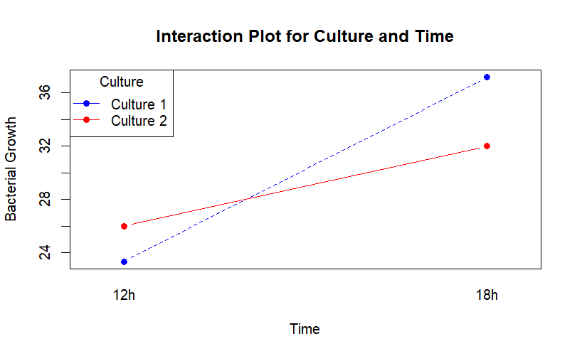

```r
library(ggplot2)

interaction.plot(x.factor = bacteria_data$Time,
                 trace.factor = bacteria_data$Culture,
                 response = bacteria_data$Growth,
                 type = "b",
                 pch = 19,
                 col = c("blue", "red"),
                 xlab = "Time",
                 ylab = "Bacterial Growth",
                 legend = FALSE,
                 main = "Interaction Plot for Culture and Time")

legend("topleft",
       legend = c("Culture 1", "Culture 2"),
       col = c("blue", "red"),
       pch = 19,
       lty = 1,
       title = "Culture",
       xpd = TRUE)
```

### The bacterial growth for Culture 1 seems to start lower at 12h than Culture 2 but ends up having a larger amount of bacterial growth by 18h. In other words, bacterial growth for Culture 1 is more rapid than Culture 2 as can be seem by the slopes of the two lines corresponding to the two cultures.

### (d). Fit an appropriate model to investigate the relationship between the bacteria growth and factor variable(s) of interest.

```r
anova_model <- aov(Growth ~ Culture * Time, data = bacteria_data)
summary(anova_model)
```

```
             Df Sum Sq Mean Sq F value   Pr(>F)
Culture       1    9.4     9.4   1.835 0.190617
Time          1  590.0   590.0 115.506 9.29e-10 ***
Culture:Time  1   92.0    92.0  18.018 0.000397 ***
Residuals    20  102.2     5.1
---
Signif. codes:  0 ‘***’ 0.001 ‘**’ 0.01 ‘*’ 0.05 ‘.’ 0.1 ‘ ’ 1
```

### (e). At 5% significance level, test if the effect of culture on the growth depends on the time. Set up appropriate null and alternative hypotheses and complete the test.

### $H_0$: The effect of culture on bacterial growth does not depend on time

### $H_1$: THe effect of culture on bacterial growth does depend on time

### The p-value for Culture:Time is 0.000397 which is less than 0.05. We reject the null hypothesis and accept the alternative hypothesis, implying that the effect of culture on bacterial growth does depend on time.

### (f). Check the validity of the model assumptions.

### Linearity: Judging from the interaction plot, the relationship between time and bacterial growth seems to be linear.

### Independence: The researcher made the runs in a random order, so we can assume independence.

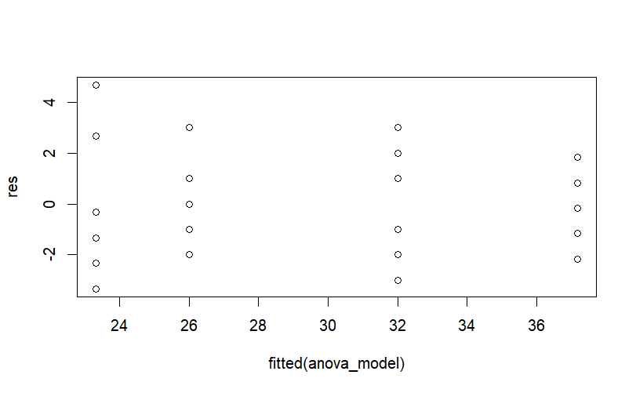

```r
res <- resid(anova_model)
plot(fitted(anova_model), res)
```

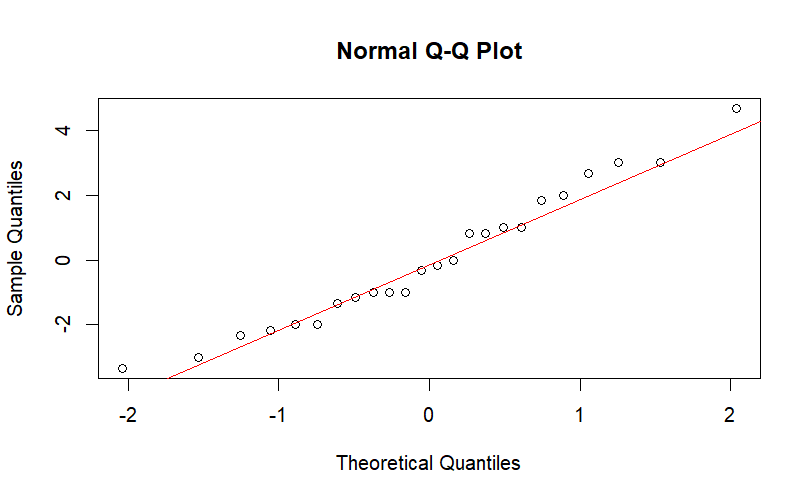

```r
qqnorm(res)
qqline(res, col = 'red')
```

### Normality: From the QQ plot, the points follow the reference line pretty closely, so we can assume normality.

### Equal Variance: From the residual plot, the points seem to be evenly scattered around the zero horizontal line so we can assume equal variance.

### (g). Researcher wants your gelp with answering below questions. Use R to produce any outputs you used to answer these questions. Using the generated outputs, provide statistical conclusions for the questions.

### (i). For the bacteria cultivated on medium 1, is there a significant difference in average growth between leaving for 18 hours as opposed to 12 hours?

### $H_0: \mu_{18} = \mu_{12}$

### $H_1: \mu_{18} \neq \mu_{12}$

### The subscripts pertain to the hour. From the t-test and using a 5% significance level, we get a p-value of $1.893 \times 10^-5 < 0.05$. Therefore, we reject the null hypothesis and accept the alternative hypothesis, indicating that there is a significant difference in average growth between leaving for 18 hours as opposed to 12 hours for medium 1.

```r
medium_1_data <- subset(bacteria_data, Culture == "C1")
t_test_medium_1 <- t.test(Growth ~ Time, data = medium_1_data)
print(t_test_medium_1)
```

```
    Welch Two Sample t-test

data:  Growth by Time
t = -9.9346, df = 7.1748, p-value = 1.893e-05
alternative hypothesis: true difference in means between group 12h and group 18h is not equal to 0
95 percent confidence interval:
 -17.10974 -10.55693
sample estimates:
mean in group 12h mean in group 18h
         23.33333          37.16667
```

### (ii). For the bacteria cultivated on medium 2, is there a significant difference in average growth between leaving for 18 hours as opposed to 12 hours?

### $H_0: \mu_{18} = \mu_{12}$

### $H_1: \mu_{18} \neq \mu_{12}$

### Once again, the subscripts pertain to the hour. From the t-test and using a 5% significance level, we get a p-value of 0.0007118 < 0.05. Therefore, we reject the null hypothesis and accept the alternative hypothesis, indicating that there is a significant difference in avearge growth between leaving for 18 hours as opposed to 12 hours for medium 2

```r
medium_2_data <- subset(bacteria_data, Culture == "C2")
t_test_medium_2 <- t.test(Growth ~ Time, data = medium_2_data)
t_test_medium_2
```

```
    Welch Two Sample t-test

data:  Growth by Time
t = -4.9543, df = 9.3077, p-value = 0.0007118
alternative hypothesis: true difference in means between group 12h and group 18h is not equal to 0
95 percent confidence interval:
 -8.725865 -3.274135
sample estimates:
mean in group 12h mean in group 18h
               26                32
```

### Question 2: Audiologists use standard lists of 50 words for test hearing in which the words were calibrated using subjects with normal hearing to make 50 words in the list equally hard to hear. The goal of the study is to compare four such lists. In the study, 24 subjects have listened to each of the 4 lists in a noisy background. The order in which they listened was randomized and the percentage of correctly recognized words is provided in the HearingTest dataset in Stat2Data package.